# R Notebook

```r
options(repos = c(CRAN = "https://cloud.r-project.org"))
```

# 1. Build a random forest model that can predict cell-of-origin (COO) using the training/testing cohort (70/30 training/testing split). Tune the model to select an appropriate number of trees and try value to produce the lowest out of bag(OOB) error. Report the error of the model in the trining and testing cohort(OOB, type 1, type 2 errors and a ROC curve). Discuss how well your model works on these data.

```r
library(Biobase)
library(randomForest)
library(caret)
library(pROC)
library(tidyverse)
cohort2 <- readRDS("/Users/emily/Desktop/For_LAQ1_required_data/DLBCL_cohort_2/DLBCL.cohort.2.rds")
set.seed(123)
ind <- sample(1:2, ncol(cohort2), replace = TRUE, prob = c(0.7,0.3))
train <- cohort2[,ind==1]
test <- cohort2[,ind==2]
train.rf <- cbind(COO = as.factor(train$COO),
                 t(exprs(train)) %>% as.data.frame())
test.rf <- cbind(COO = as.factor(test$COO),
                t(exprs(test)) %>% as.data.frame())
tune <- tuneRF(train.rf[,-1], train.rf$COO,
               ntreeTry=100,
               stepFactor=1.5,
               improve=0.01)
```

```
## mtry = 128  OOB error = 3.98%
## Searching left ...
## mtry = 86    OOB error = 3.59%
## 0.1 0.01
## mtry = 58    OOB error = 4.78%
## -0.3333333 0.01
## Searching right ...
## mtry = 192   OOB error = 1.99%
## 0.4444444 0.01
## mtry = 288   OOB error = 3.98%
## -1 0.01
```

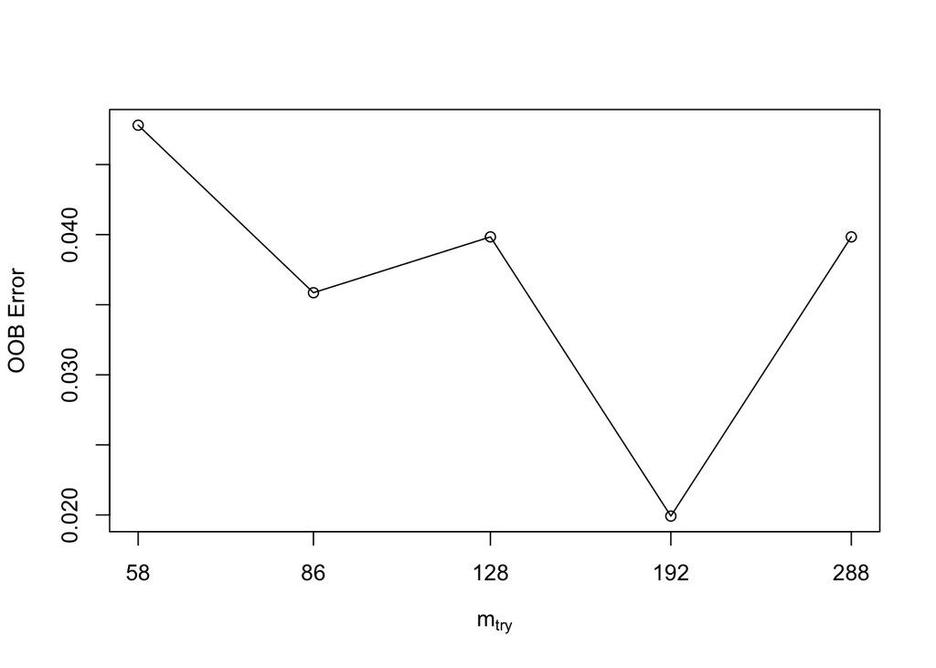

```r
best.mtry <- tune[which.min(tune[,2]),1]
rf <- randomForest(train.rf[,-1], train.rf$COO,
                   ntree=200,
                   mtry=best.mtry)
print(rf)
```

```
##
## Call:
##  randomForest(x = train.rf[, -1], y = train.rf$COO, ntree = 200,      mtry = best.mtry)
##                Type of random forest: classification
##                      Number of trees: 200
## No. of variables tried at each split: 192
##
##         OOB estimate of  error rate: 4.38%
## Confusion matrix:
##     ABC GCB class.error
## ABC 106   8  0.07017544
## GCB   3 134  0.02189781
```

```r
train.pred <- predict(rf, train.rf)
confusionMatrix(train.pred, train.rf$COO)
```

```
## Confusion Matrix and Statistics
##
##           Reference
## Prediction ABC GCB
##        ABC 114   0
##        GCB   0 137
##
##                Accuracy : 1
##                  95% CI : (0.9854, 1)
##     No Information Rate : 0.5458
##     P-Value [Acc > NIR] : < 2.2e-16
##
##                   Kappa : 1
##
##  Mcnemar's Test P-Value : NA
##
##             Sensitivity : 1.0000
##             Specificity : 1.0000
##          Pos Pred Value : 1.0000
##          Neg Pred Value : 1.0000
##              Prevalence : 0.4542
##          Detection Rate : 0.4542
##    Detection Prevalence : 0.4542
##       Balanced Accuracy : 1.0000
##
##        'Positive' Class : ABC
##
```

```r
train.prob <- predict(rf, train.rf, type="prob")
roc.train <- roc(train.rf$COO, train.prob[,2])
```

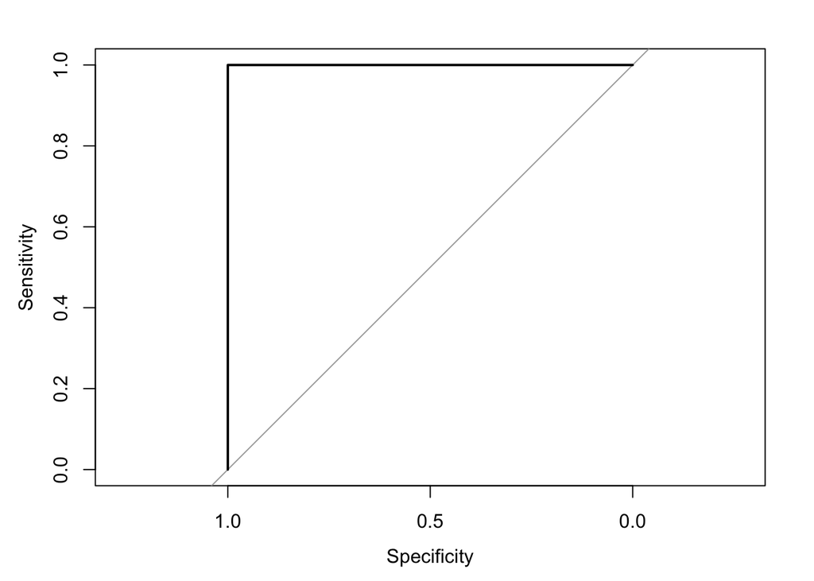

```r
plot(roc.train)
```

```r
test.pred <- predict(rf, test.rf)
confusionMatrix(test.pred, test.rf$COO)
```

```
## Confusion Matrix and Statistics
##
##           Reference
## Prediction ABC GCB
##        ABC  51   0
##        GCB   2  46
##
##                Accuracy : 0.9798
##                  95% CI : (0.9289, 0.9975)
##     No Information Rate : 0.5354
##     P-Value [Acc > NIR] : <2e-16
##
##                   Kappa : 0.9595
##
##  Mcnemar's Test P-Value : 0.4795
##
##             Sensitivity : 0.9623
##             Specificity : 1.0000
##          Pos Pred Value : 1.0000
##          Neg Pred Value : 0.9583
##              Prevalence : 0.5354
##          Detection Rate : 0.5152
##    Detection Prevalence : 0.5152
##       Balanced Accuracy : 0.9811
##
##        'Positive' Class : ABC
##
```

```r
test.prob <- predict(rf, test.rf, type="prob")
roc.test <- roc(test.rf$COO, test.prob[,2])
```

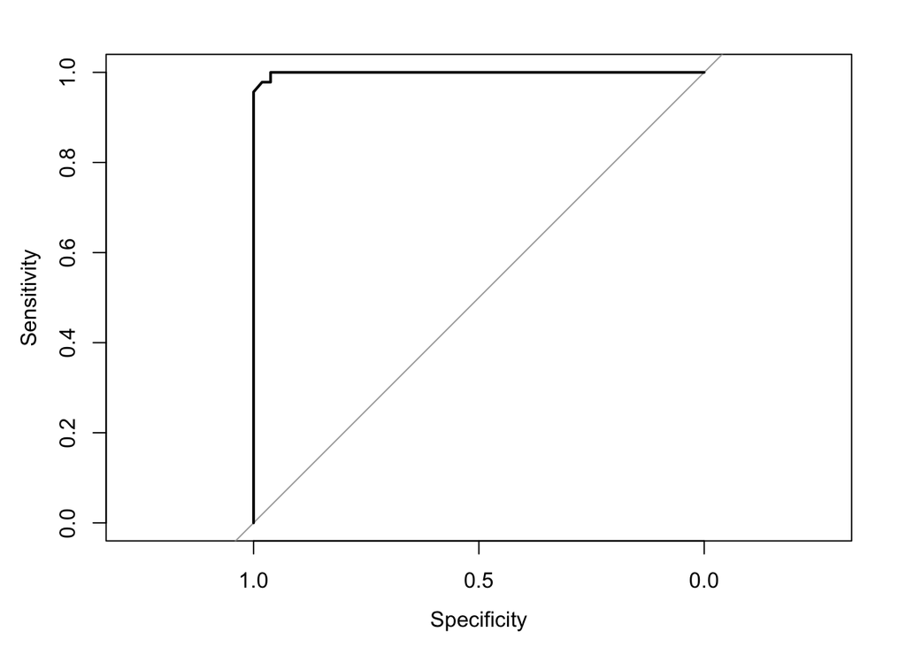

```r
plot(roc.test)
```

The optimal mtry value was 192, which gave the lowest OOB error during tuning (~1.99%). The final model had an OOB error of 4.38%. From the confusion matrix, the type 1 error was 7.02% and the type 2 error was 2.19%. This shows the model performs slightly better for GCB than ABC. The sensitivity was 0.9623 and specificity was 1.0000, with a balanced accuracy of 0.9811. The ROC curve shows an AUC close to 1, indicating very strong classification performance.

# 2. Select the 1000 most important features in the model and use these to recreate the model - Report the error of this model in the training and testing cohort(OOB, type 1, type 2 errors & ROC). Discuss whether it performs better or worse than the previous model.

```r
imp <- importance(rf) %>% as.data.frame()
top1000 <- rownames(imp %>% arrange(-MeanDecreaseGini))[1:1000]
train.rf.1000 <- train.rf[, c("COO", top1000)]
test.rf.1000 <- test.rf[, c("COO", top1000)]
rf.1000 <- randomForest(train.rf.1000[,-1], train.rf.1000$COO,
                        ntree=200, mtry=sqrt(1000))
print(rf.1000)
```

```
##
## Call:
##  randomForest(x = train.rf.1000[, -1], y = train.rf.1000$COO,      ntree = 200, mtry = sqrt(1000))
##                Type of random forest: classification
##                      Number of trees: 200
## No. of variables tried at each split: 32
##
##         OOB estimate of  error rate: 1.2%
## Confusion matrix:
##     ABC GCB class.error
## ABC 112   2  0.01754386
## GCB   1 136  0.00729927
```

This model reduced the OOB error to 1.2%, compared to 4.38% in the previous model. The type 1 error decreased to 1.75% and the type 2 error decreased to 0.73%, showing improved performance for both classes. The model performs better with fewer features, suggesting that removing less informative genes improves classification accuracy.

# 3. Recursively retain the model using the n most important features (where n is a reducing number of features) to find the optimum number of genes to include in the training. Report the error of the model in the training and testing cohort, including OBB, type 1, type 2 errors & ROC. Discuss the n value chosen, explaining your strategy for gene selection and describe which of the 3 models you feel best models the data.

```r
feature_sizes <- c(1000, 500, 200, 100, 50, 20)
results <- data.frame()
for (n in feature_sizes) {
  genes <- rownames(imp %>% arrange(-MeanDecreaseGini))[1:n]
  train.sub <- train.rf[, c("COO", genes)]
  test.sub <- test.rf[, c("COO", genes)]
  model <- randomForest(train.sub[,-1], train.sub$COO,
                        ntree=150, mtry=sqrt(n))
  test.pred <- predict(model, test.sub)
  cm <- confusionMatrix(test.pred, test.sub$COO)
  acc <- cm$overall["Accuracy"]
  results <- rbind(results, data.frame(n=n, accuracy=acc))}
results
```

|  | n | accuracy |
| --- | --- | --- |
| Accuracy | 1000 | 0.969697 |
| Accuracy1 | 500 | 0.979798 |
| Accuracy2 | 200 | 0.989899 |
| Accuracy3 | 100 | 0.979798 |
| Accuracy4 | 50 | 0.989899 |
| Accuracy5 | 20 | 0.969697 |

# 4. Using your final optimum model, predict the cell of origin in Cohort 1 (the cohort used in the practical). Report the type 1 and type 2 errors and aROC curve in this validation cohort. Discuss whether this model works within this validation cohort and explain your reasoning.

```r
cohort1 <- Biobase::combine(
  readRDS("/Users/emily/Desktop/For_LAQ1_required_data/DLBCL_cohort_1/DLBCL.eSet.1.rds"),
  readRDS("/Users/emily/Desktop/For_LAQ1_required_data/DLBCL_cohort_1/DLBCL.eSet.2.rds"),
  readRDS("/Users/emily/Desktop/For_LAQ1_required_data/DLBCL_cohort_1/DLBCL.eSet.3.rds"),
  readRDS("/Users/emily/Desktop/For_LAQ1_required_data/DLBCL_cohort_1/DLBCL.eSet.4.rds"))

final.genes <- rownames(imp %>% arrange(-MeanDecreaseGini))[1:100]
cohort1.rf <- cbind(COO=as.factor(cohort1$COO),
                    t(exprs(cohort1)) %>% as.data.frame())
cohort1.sub <- cohort1.rf[, c("COO", final.genes)]

pred <- predict(model, cohort1.sub)
confusionMatrix(pred, cohort1.sub$COO)
```

```
## Confusion Matrix and Statistics
##
##           Reference
## Prediction ABC GCB
##        ABC 228 110
##        GCB  27 433
##
##                Accuracy : 0.8283
##                  95% CI : (0.8003, 0.8539)
##     No Information Rate : 0.6805
##     P-Value [Acc > NIR] : < 2.2e-16
##
##                   Kappa : 0.6366
##
##  Mcnemar's Test P-Value : 2.457e-12
##
##             Sensitivity : 0.8941
##             Specificity : 0.7974
##          Pos Pred Value : 0.6746
##          Neg Pred Value : 0.9413
##              Prevalence : 0.3195
##          Detection Rate : 0.2857
##    Detection Prevalence : 0.4236
##       Balanced Accuracy : 0.8458
##
##        'Positive' Class : ABC
##
```

```r
prob <- predict(model, cohort1.sub, type="prob")
roc.val <- roc(cohort1.sub$COO, prob[,2])
```

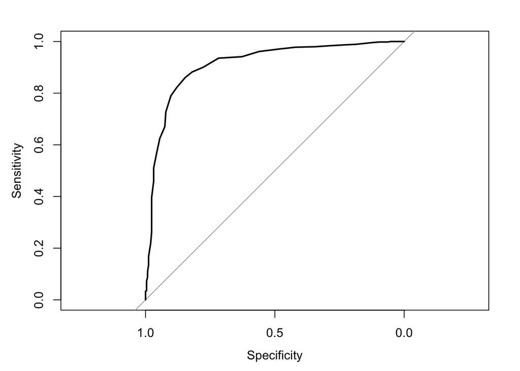

```r
plot(roc.val)
```

The sensitivity of this model was 0.8941 and specificity was 0.7974, with a balanced accuracy of 0.8458. Compared to the training and testing results, the performance decreased, indicating that the model does not generalise perfectly to independent data. The ROC curve shows an AUC of approximately 0.88–0.90, suggesting that the model still has good predictive ability. The model performs reasonably well in the validation cohort, but the drop in performance suggests some overfitting during training.

<LAQ 2>

# 1.Perform the unsupervised clustering analysis using non-negative matrix factorisation(NMF). Find the most appropriate number of clusters, and provide all the essential statistics and plots to support your cluster.

```r
library(NMF)
```

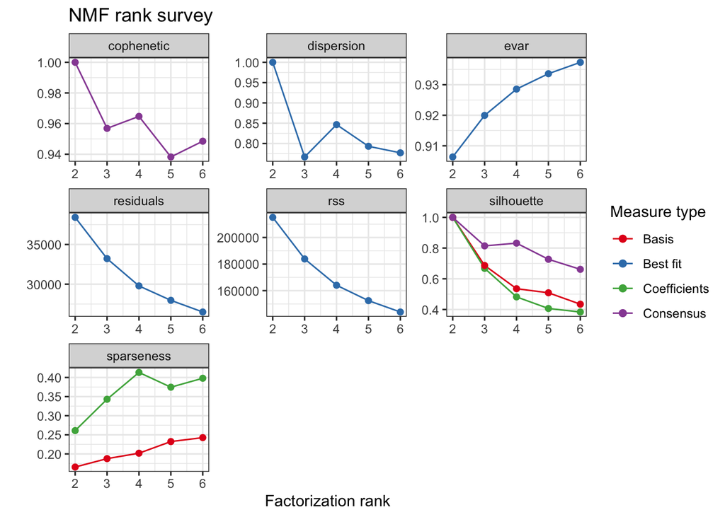

```r
exp_data <- read.table("/Users/emily/Desktop/For_LAQ2_required_data/exp_data_ESCC_90samples.txt", header=TRUE, row.names=1)
mads <- apply(exp_data,1,mad)
d_exp <- exp_data[rev(order(mads))[1:1500],]
estim.r <- nmf(d_exp, 2:6, nrun=10, seed=123456)
plot(estim.r)
```

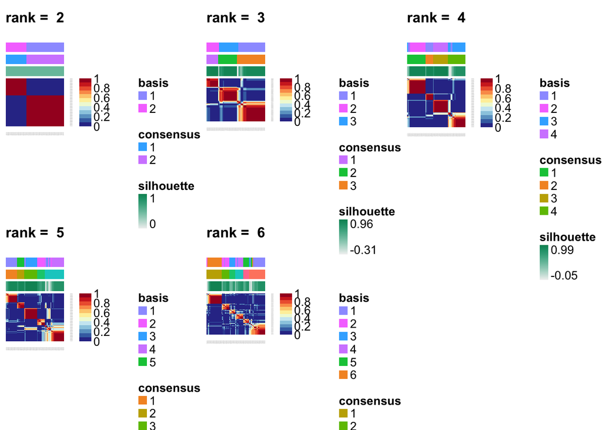

```r
consensusmap(estim.r)
```

```r
res <- nmf(d_exp, 4, "brunet", seed=123456)
nmf_cluster <- predict(res)
table(nmf_cluster)
```

```
## nmf_cluster
##  1  2  3  4
## 21 33 13 23
```

The consensus map at k=4 shows clearer cluster structure, while higher k values appear more unstable. At k=4, the cophenetic coefficient shows a local increase before decreasing again, and the silhouette score also improves slightly compared to k=3. I selected k=4 as the most appropriate number of clusters, and the samples were divided into four groups (21, 33, 13, and 23), suggesting a reasonable clustering structure.

# 2. Based on your selection of number of clusters, select and report the most significant gene signatures for each cluster (i.e., top 20 genes based on the differential expression of each cluster against all others.)

```r
library(limma)
cl <- nmf_cluster
limma_res <- list()
for (i in 1:4) {
  coi <- d_exp[, cl==i]
  rc  <- d_exp[, cl!=i]
  factors <- factor(rep(c("coi","others"),
                 c(ncol(coi), ncol(rc))))
  mm <- model.matrix(~factors-0)
  colnames(mm) <- levels(factors)
  fit <- lmFit(cbind(coi, rc), mm)
  contrast <- makeContrasts(coi-others, levels=mm)
  fit2 <- contrasts.fit(fit, contrast)
  fit2 <- eBayes(fit2)
  deg <- topTable(fit2, number=20)
  limma_res[[i]] <- deg
  print(paste("Cluster", i))
  print(head(deg, 20))}
```

```
## [1] "Cluster 1"
##              logFC   AveExpr        t      P.Value    adj.P.Val        B
## MT-ND5   11.456269 10.149411 24.39159 4.018854e-43 6.028281e-40 84.37685
## VIM       9.394897  7.735001 21.03291 7.101016e-38 5.325762e-35 73.47184
## FLNA      9.398716  8.030110 20.12768 2.290353e-36 1.145177e-33 70.28783
## AF079515  9.259422  8.246427 19.54390 2.266168e-35 8.498128e-33 68.17626
## FTL       9.781775  9.835862 18.92819 2.658691e-34 7.976073e-32 65.89875
## CD74     10.663949  8.778400 18.76182 5.213020e-34 1.303255e-31 65.27440
## AF113016  9.502621  8.961681 18.52635 1.360009e-33 2.914306e-31 64.38409
## IFI30     7.940020  6.568168 18.05043 9.647689e-33 1.808942e-30 62.56102
## TIMP1     8.032038  6.268484 17.83605 2.353718e-32 3.922864e-30 61.72940
## MALAT1    8.906858  8.331041 17.48799 1.013833e-31 1.520749e-29 60.36540
## BC078172  8.576542  6.812392 17.44512 1.214890e-31 1.656668e-29 60.19623
## DQ590013 11.210764  9.093174 17.29104 2.332308e-31 2.895095e-29 59.58599
## HLA-C     9.138293  8.545344 17.27382 2.509082e-31 2.895095e-29 59.51760
## A2M       8.304313  5.710562 16.56632 5.219317e-30 5.476318e-28 56.67059
## DM074112  9.428107  8.857487 16.55523 5.476318e-30 5.476318e-28 56.62541
## tRNA_Pro  9.589880  8.704740 16.34567 1.362508e-29 1.247141e-27 55.76816
## HLA-DRA   9.257394  7.286671 16.33726 1.413426e-29 1.247141e-27 55.73364
## TPM2      8.162932  5.509460 16.30899 1.599106e-29 1.332588e-27 55.61747
## HLA-A     8.159183  7.998682 16.29273 1.716784e-29 1.355356e-27 55.55064
## TIMP2     7.742523  5.838470 16.07916 4.377662e-29 3.172842e-27 54.66901
## [1] "Cluster 2"
##              logFC   AveExpr        t      P.Value    adj.P.Val        B
## SFN      11.744633  9.912489 29.12763 1.281619e-49 1.922428e-46 99.45631
## S100A2   11.916713  9.590043 25.94431 2.603220e-45 1.952415e-42 90.44112
## ITGA3     8.812180  6.160461 25.23442 2.696438e-44 1.348219e-41 88.29112
## DM074112 10.662472  8.857487 24.77655 1.250013e-43 4.687550e-41 86.87568
## SLC2A1    9.619204  7.638533 24.45721 3.688515e-43 1.106555e-40 85.87490
## MT-ND5    9.345822 10.149411 23.77988 3.788689e-42 9.471723e-40 83.71443
## TYMP      8.440830  6.923588 23.40029 1.427068e-41 3.058004e-39 82.48081
## LGALS1   10.111576  8.292240 23.34458 1.735956e-41 3.146740e-39 82.29833
## SLC7A5    8.471993  7.185581 23.32073 1.888044e-41 3.146740e-39 82.22010
## NDRG1     9.923965  7.293529 22.79837 1.206019e-40 1.809028e-38 80.49022
## ITGA6     8.688574  6.658527 22.44529 4.295199e-40 5.857090e-38 79.30256
## KRT6A    13.498314 11.122073 22.24170 8.989950e-40 1.123744e-37 78.61093
## KRT17    12.697055 10.588738 21.68331 6.979569e-39 7.529590e-37 76.68806
## AF113016  9.186130  8.961681 21.68146 7.027617e-39 7.529590e-37 76.68162
## FLNA      8.557838  8.030110 21.52369 1.262047e-38 1.262047e-36 76.13131
## MT2A     10.332230  8.415747 21.33288 2.571757e-38 2.379318e-36 75.46164
```

[output cut: 33 more lines]

```
## SLC9A3R1      8.857296  6.762043 22.15936 1.181271e-39 2.953178e-37 77.48864
## PGD          10.240843  6.749444 21.92471 2.790239e-39 5.979084e-37 76.70257
## CBR1          9.040479  5.405450 20.97020 9.819178e-38 1.841096e-35 73.43295
## EPHX1         9.550521  6.230511 20.65138 3.301920e-37 5.503199e-35 72.31470
## MT-ND5        9.554731 10.149411 20.54323 4.995886e-37 7.493829e-35 71.93233
## TP63          8.331651  6.618768 20.36967 9.738100e-37 1.327923e-34 71.31550
## GPC1          8.599685  7.041839 19.77644 9.795369e-36 1.224421e-33 69.17689
## ABHD4         6.832542  4.540428 19.39771 4.372265e-35 5.044921e-33 67.78682
## TM4SF1        7.511104  6.258290 18.94722 2.651041e-34 2.840401e-32 66.10795
## SFN           9.763635  9.912489 18.70270 7.125191e-34 7.012138e-32 65.18505
## ATP1B1        8.221582  6.481106 18.69075 7.479614e-34 7.012138e-32 65.13971
## NQO1          9.813827  5.583336 18.56443 1.250399e-33 1.103293e-31 64.65948
## LOC100133286  7.965201  4.386001 18.48511 1.728309e-33 1.440258e-31 64.35681
## PTGR1         7.878803  4.253888 18.10433 8.264679e-33 6.524747e-31 62.89163
## AF079515      8.369967  8.246427 17.97874 1.390307e-32 1.042730e-30 62.40394
```

Cluster 1 : VIM, CD74, HLA-A/C/DRA, and IFI30. Cluster 2 : KRT6A, KRT17, KRT14 and SLC2A1. Cluster 3 : CSTB, CD24, ANXA1, and S100A9. Cluster 4 : G6PD, NQO1, TXN, and TKT.

# 3. Perform GSEA and report the most unregulated pathways for each cluster, and comment on your findings.

```r
install.packages("BiocManager")
BiocManager::install("clusterProfiler")
BiocManager::install("org.Hs.eg.db")
```

```r
BiocManager::install("enrichplot")
BiocManager::install("DOSE")
library(clusterProfiler)
library(org.Hs.eg.db)
gene_lists <- list()
for (i in 1:4) {
  coi <- d_exp[, cl == i]
  rc  <- d_exp[, cl != i]
  factors <- factor(rep(c("coi","others"),
                 c(ncol(coi), ncol(rc))))
  mm <- model.matrix(~factors - 0)
  colnames(mm) <- levels(factors)
  fit <- lmFit(cbind(coi, rc), mm)
  contrast <- makeContrasts(coi - others, levels = mm)
  fit2 <- contrasts.fit(fit, contrast)
  fit2 <- eBayes(fit2)
  res <- topTable(fit2, number = Inf)
  gene_list <- res$logFC
  names(gene_list) <- rownames(res)
  gene_list <- gene_list[!is.na(gene_list)]
  gene_list <- sort(gene_list, decreasing = TRUE)
  gene_lists[[i]] <- gene_list}

GSEA_res <- list()
for (i in 1:4) {
  gse <- gseGO(
    geneList = gene_lists[[i]],
    OrgDb = org.Hs.eg.db,
    keyType = "SYMBOL",
    ont = "BP",
    pvalueCutoff = 0.05)
  GSEA_res[[i]] <- gse}
```

[output not shown]

[output not shown]

[output not shown]

[output not shown]

[output not shown]

[output not shown]

[output not shown]

[output not shown]

[output not shown]

[output not shown]

[output not shown]

[output not shown]

[output not shown]

[output not shown]

[output not shown]

[output not shown]

[output not shown]

[output not shown]

[output not shown]

[output not shown]

```r
for (i in 1:4) {
  print(paste("Cluster", i))
  print(head(as.data.frame(GSEA_res[[i]]), 10))}
```

```
## [1] "Cluster 1"
##                    ID                                   Description setSize
## GO:0040011 GO:0040011                                    locomotion     208
## GO:0016477 GO:0016477                                cell migration     246
## GO:0048870 GO:0048870                                 cell motility     257
## GO:0097435 GO:0097435             supramolecular fiber organization      89
## GO:0040012 GO:0040012                      regulation of locomotion     175
## GO:0051128 GO:0051128 regulation of cellular component organization     231
## GO:0007155 GO:0007155                                 cell adhesion     258
## GO:0006956 GO:0006956                         complement activation      16
## GO:0030334 GO:0030334                  regulation of cell migration     166
## GO:2000145 GO:2000145                   regulation of cell motility     172
##            enrichmentScore      NES       pvalue     p.adjust       qvalue rank
## GO:0040011       0.4356192 1.647751 4.304523e-08 3.944868e-05 2.833199e-05  439
## GO:0016477       0.4296506 1.632355 3.469718e-08 3.944868e-05 2.833199e-05  465
## GO:0048870       0.4216005 1.606086 6.449375e-08 3.944868e-05 2.833199e-05  465
## GO:0097435       0.5054471 1.821322 2.520568e-07 7.495872e-05 5.383526e-05  481
## GO:0040012       0.4414575 1.656431 2.690014e-07 7.495872e-05 5.383526e-05  439
## GO:0051128       0.4204322 1.595547 1.654549e-07 7.495872e-05 5.383526e-05  503
## GO:0007155       0.4130908 1.573536 2.859461e-07 7.495872e-05 5.383526e-05  414
## GO:0006956       0.7818600 2.252596 3.363726e-07 7.715546e-05 5.541296e-05  157
## GO:0030334       0.4472780 1.674409 4.640324e-07 9.461105e-05 6.794954e-05  439
## GO:2000145       0.4408992 1.652997 8.813108e-07 1.617205e-04 1.161475e-04  439
##                              leading_edge
## GO:0040011 tags=50%, list=29%, signal=41%
## GO:0016477 tags=50%, list=31%, signal=42%
## GO:0048870 tags=49%, list=31%, signal=41%
## GO:0097435 tags=62%, list=32%, signal=45%
## GO:0040012 tags=51%, list=29%, signal=41%
## GO:0051128 tags=51%, list=34%, signal=40%
## GO:0007155 tags=45%, list=28%, signal=40%
## GO:0006956 tags=69%, list=10%, signal=62%
## GO:0030334 tags=53%, list=29%, signal=42%
## GO:2000145 tags=52%, list=29%, signal=41%
##                                                                                                                                                                                                                                                                                                          …
## GO:0040011                                                                                                                                       CD74/COL1A1/COL3A1/FN1/FLNA/SPARC/MALAT1/ACTA2/COL6A1/TIMP1/…
## GO:0016477             CD74/COL1A1/COL3A1/FN1/FLNA/SPARC/ACTA2/TIMP1/DCN/APOE/C3/MM…
## GO:0048870 CD74/COL1A1/COL3A1/FN1/FLNA/SPARC/MALAT1/ACTA2/TIMP1/DCN/APO…
## GO:0097435                                                                                                                                                                                                                                                                                               …
## GO:0040012                                                                                                                                                                                                                    CD74/COL1A1/COL3A1/FN1/FLNA/SPARC/MALAT1/ACTA2/TIMP1/DCN/APO…
```

[output cut: 136 more lines]

```
## GO:0043588 tags=45%, list=25%, signal=36%
## GO:0030216 tags=45%, list=21%, signal=36%
## GO:0006082 tags=41%, list=25%, signal=33%
## GO:0043436 tags=41%, list=25%, signal=33%
##                                                                                                                                                                                                                                                                         core_enrichment
## GO:0009636                                                                                                                   AKR1B10/GPX2/CES1/TXN/ALDH1A1/NQO1/EPHX1/S100A9/SRXN1/TXNRD1/GSTM3/SLC7A11/GSR/ABCC5/BMP7/COL6A1/CLDN1/MGST1/NUPR1/LCN2/FOS/MT2A/NEFL/MT1X/GSTM1/AHR/MAP1B
## GO:0006805                                                                                                                                                                                          ALDH3A1/NQO1/EPHX1/CBR1/ABCC1/CYP2S1/GSTM3/UGT1A1/GSTM4/ABCC5/GSTM1/AHR/ABCC3/GSTA4
## GO:0009410                                                                                                          ALDH3A1/COL1A1/NQO1/EPHX1/CBR1/ABCC1/CYP2S1/GSTM3/TFRC/UGT1A1/GSTM4/GCLM/UCHL1/ABCC5/GCLC/MMP2/COL6A1/CCND1/IGFBP2/LCN2/FOS/GSTM1/SFRP2/AHR/MAP1B/ABCC3/TXNIP/GSTA4
## GO:0071466                                                                                                                                                                               ALDH3A1/NQO1/EPHX1/CBR1/ABCC1/CYP2S1/GSTM3/TFRC/UGT1A1/GSTM4/UCHL1/ABCC5/GSTM1/AHR/ABCC3/GSTA4
## GO:0097305                                                                                                                                                                                 AKR1C3/AKR1C2/CES1/ADH7/G6PD/SOX2/S100A8/TNC/CCND1/CLDN1/SGK1/FOS/SCNN1A/NEFL/AHR/EPS8/FGFR2
## GO:0019752                                 AKR1C3/AKR1C2/CES1/ADH7/CYP4F11/PGD/ODC1/ALDH1A1/EPHX1/CBR1/…
## GO:0043588 AKR1C3/KRT17/KRT6A/COL1A1/SFN/SPRR1B/SPRR1A/SPRR3/COL1A2/COL…
## GO:0030216                                                                                                                           AKR1C3/KRT17/KRT6A/SFN/SPRR1B/SPRR1A/SPRR3/TP63/CSTA/ANXA1/WNT5A/ZFP36/KRT14/KRT6B/SPRR2E/KRT16/SPRR2D/CNFN/TGM3/PPL/TXNIP/KRT6C/ETV4/KRT10/S100A7
## GO:0006082                                 AKR1C3/AKR1C2/CES1/ADH7/CYP4F11/PGD/ODC1/ALDH1A1/EPHX1/CBR1/…
## GO:0043436                                 AKR1C3/AKR1C2/CES1/ADH7/CYP4F11/PGD/ODC1/ALDH1A1/EPHX1/CBR1/…
```

Cluster 1 : cell migration, cell adhesion, and locomotion-related pathways Cluster 2 : response to stimulus, defense response, and immune-related pathways Cluster 3 : keratinization and epithelial/epidermal cell differentiation pathways Cluster 4 : xenobiotic metabolism, response to toxic substances, and metabolic processes

Each cluster shows distinct biological functions, suggesting that the clustering successfully separates biologically meaningful groups.

# 4. Repeat the procedure 1-3 above using the consensus clustering algorithm(e.g., ConsensusClusterPlus R package) and report all the required findgings.

```r
if (!requireNamespace("BiocManager", quietly = TRUE))
    install.packages("BiocManager")
BiocManager::install("ConsensusClusterPlus")
library(ConsensusClusterPlus)

consensus_res <- ConsensusClusterPlus(
  as.matrix(d_exp),
  maxK=6,
  reps=50,
  pItem=0.8,
  pFeature=1,
  clusterAlg="hc",
  distance="pearson",
  seed=123)
```

```
## end fraction
```

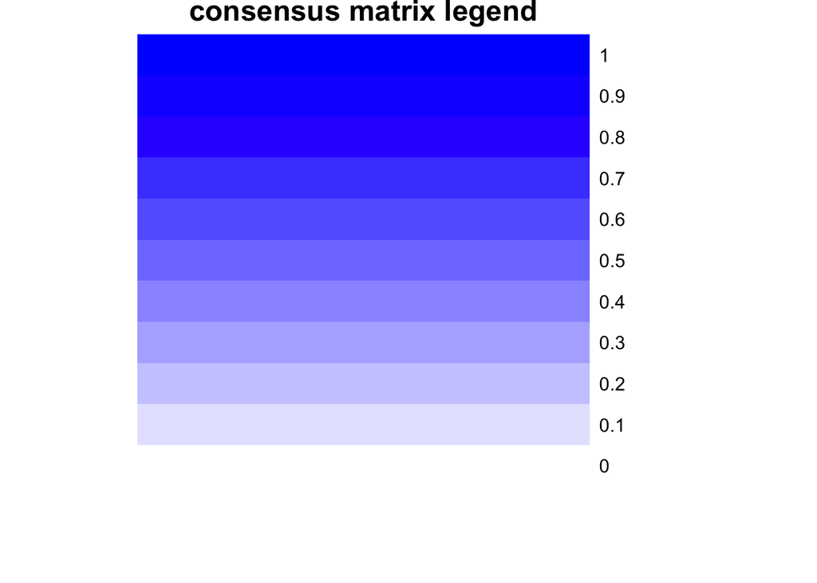

```
## clustered
```

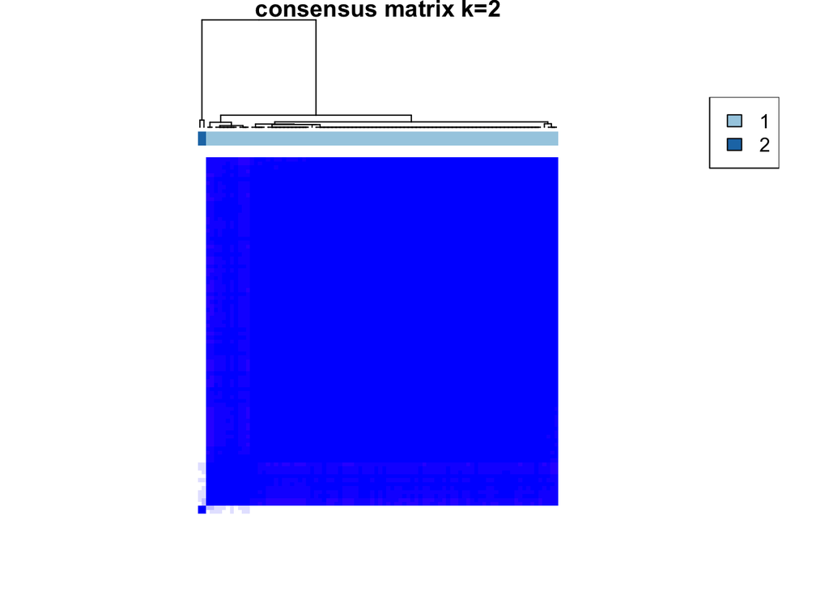

```
## clustered
```

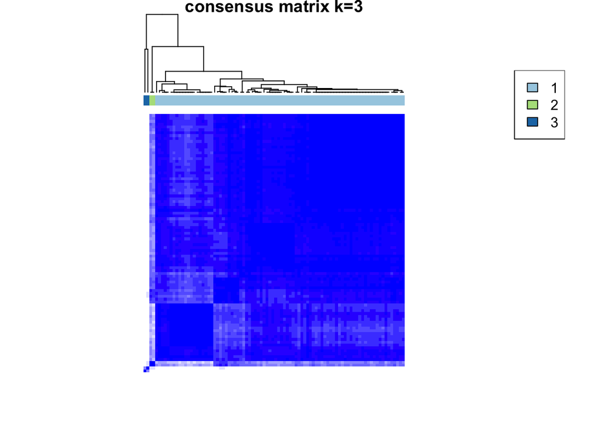

```
## clustered
```

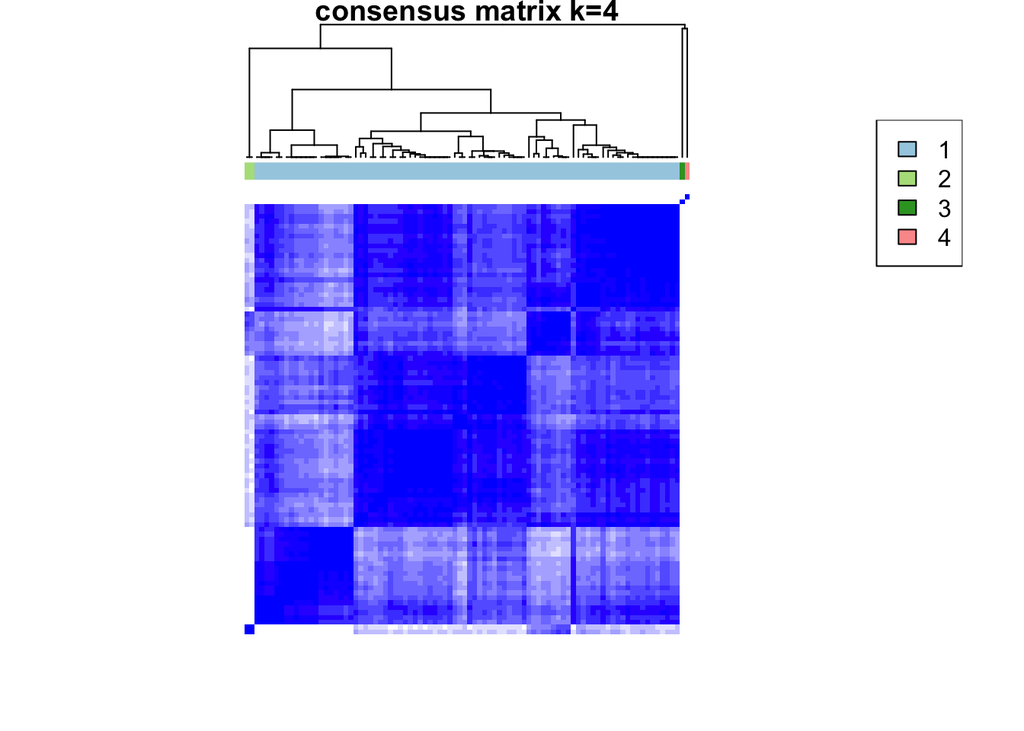

```
## clustered
```

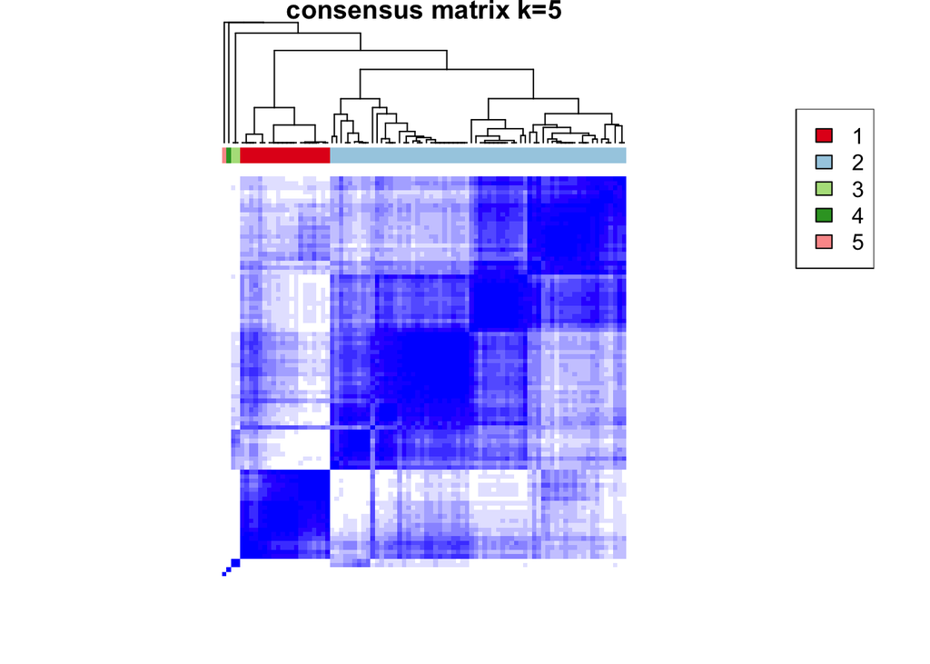

```
## clustered
```

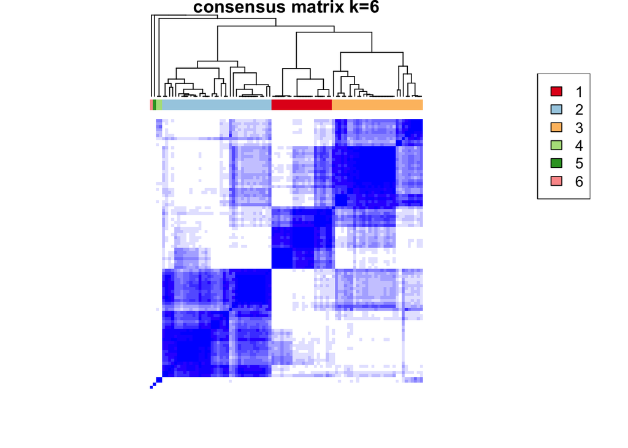

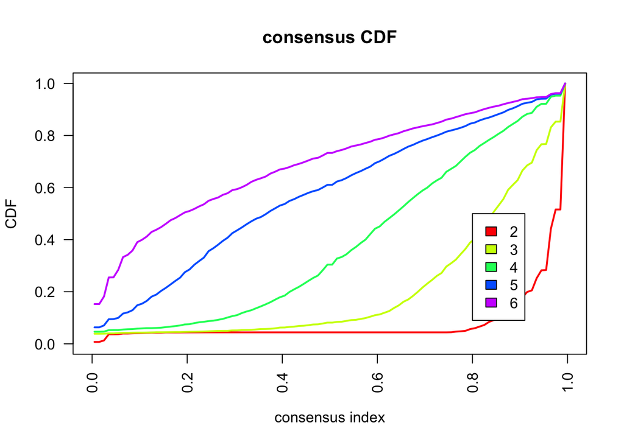

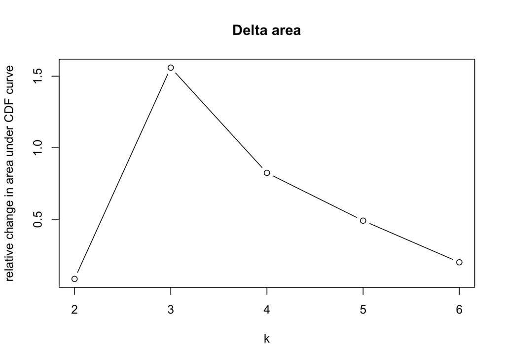

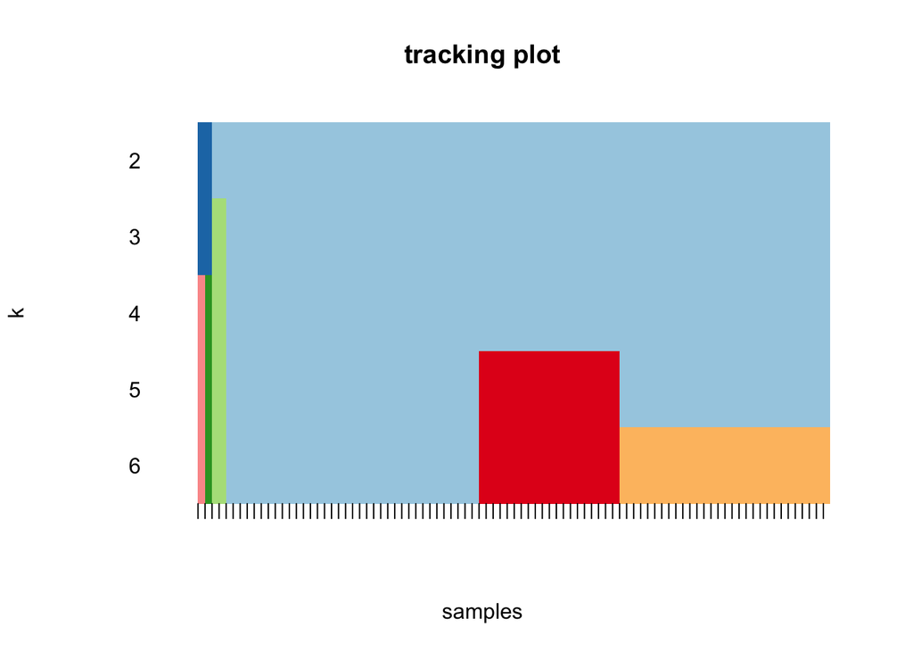

```r
cc_cluster <- consensus_res[[4]]$consensusClass
table(cc_cluster)
```

```
## cc_cluster
##  1  2  3  4
## 86  2  1  1
```

```r
library(limma)
group <- factor(cc_cluster)
design <- model.matrix(~0 + group)
colnames(design) <- paste0("C", levels(group))
fit <- lmFit(d_exp, design)
contrast.matrix <- makeContrasts(
  C1vsAll = C1 - (C2+C3+C4)/3,
  C2vsAll = C2 - (C1+C3+C4)/3,
  C3vsAll = C3 - (C1+C2+C4)/3,
  C4vsAll = C4 - (C1+C2+C3)/3,
  levels = design)
fit2 <- contrasts.fit(fit, contrast.matrix)
fit2 <- eBayes(fit2)
limma_cc <- list()
top20_genes <- list()
for(i in 1:4){
  res <- topTable(fit2, coef=i, number=Inf)
  limma_cc[[i]] <- res
  top20_genes[[i]] <- rownames(res)[1:20]}
top20_genes
```

```
## [[1]]
##  [1] "KRT6A"   "CLCA2"   "KRT6B"   "DSG3"    "TACSTD2" "SPRR1B"  "KRT16"
##  [8] "KRT6C"   "GJB2"    "MPZL2"   "KRT17"   "WNT7B"   "FXYD3"   "GBP6"
## [15] "CXCL14"  "PTPRZ1"  "SPRR1A"  "SPRR2D"  "GJB6"    "ZNF750"
##
## [[2]]
##  [1] "ERV3-1"  "HES2"    "TACSTD2" "FXYD3"   "KRT15"   "CXCL6"   "TMEM158"
##  [8] "PROM2"   "HORMAD1" "PVRL4"   "ALDH3B2" "ESPN"    "DEFB1"   "CXCL1"
## [15] "TMEM63C" "MPP7"    "LRRC17"  "FGFBP1"  "BARX2"   "DGAT2"
##
## [[3]]
##  [1] "SHISA2"  "KRT6A"   "EMILIN1" "MRPL21"  "PEG10"   "CALML3"  "TWIST1"
##  [8] "LEF1"    "KREMEN2" "HOXD13"  "ETV5"    "MFAP4"   "IFI27"   "NKD2"
## [15] "WNT10A"  "TACSTD2" "HOMER2"  "SLC16A9" "ETV4"    "ITGA3"
##
## [[4]]
##  [1] "RAB25"    "PRSS8"    "FXYD3"    "S100A14"  "FOLR2"    "TNS4"
##  [7] "PPP1R14C" "HBA1"     "HBB"      "CPA4"     "PRSS23"   "TACSTD2"
## [13] "PROM2"    "VSIG4"    "KCNK1"    "HBA2"     "CLCA2"    "EPCAM"
## [19] "LRRC17"   "MPZL2"
```

```r
library(clusterProfiler)
library(org.Hs.eg.db)
gene_lists <- list()
for (i in 1:4) {
  gene_list <- limma_cc[[i]]$logFC
  names(gene_list) <- rownames(limma_cc[[i]])
  gene_list <- sort(gene_list, decreasing = TRUE)
  gene_lists[[i]] <- gene_list}
GSEA_cc <- list()
for (i in 1:4) {
  gse <- gseGO(
    geneList = gene_lists[[i]],
    OrgDb = org.Hs.eg.db,
    keyType = "SYMBOL",
    ont = "BP",
    pvalueCutoff = 0.05)
  GSEA_cc[[i]] <- gse}
```

[output not shown]

[output not shown]

[output not shown]

[output not shown]

[output not shown]

[output not shown]

[output not shown]

[output not shown]

[output not shown]

[output not shown]

[output not shown]

[output not shown]

[output not shown]

[output not shown]

[output not shown]

[output not shown]

[output not shown]

[output not shown]

[output not shown]

[output not shown]

```r
for (i in 1:4) {
  print(paste("Cluster", i))
  print(head(as.data.frame(GSEA_cc[[i]])))}
```

```
## [1] "Cluster 1"
##                    ID                     Description setSize enrichmentScore
## GO:0009913 GO:0009913  epidermal cell differentiation      66       0.7446537
## GO:0030216 GO:0030216    keratinocyte differentiation      56       0.7523715
## GO:0008544 GO:0008544           epidermis development     106       0.7151197
## GO:0043588 GO:0043588                skin development     100       0.6732270
## GO:0030855 GO:0030855 epithelial cell differentiation     143       0.6202782
## GO:0031424 GO:0031424                  keratinization      35       0.8013342
##                 NES       pvalue     p.adjust       qvalue rank
## GO:0009913 2.176243 1.000000e-10 3.642000e-08 3.555789e-08  261
## GO:0030216 2.161941 1.000000e-10 3.642000e-08 3.555789e-08  261
## GO:0008544 2.143514 1.000000e-10 3.642000e-08 3.555789e-08  356
## GO:0043588 2.018427 1.000000e-10 3.642000e-08 3.555789e-08  356
## GO:0030855 1.886446 1.000000e-10 3.642000e-08 3.555789e-08  261
## GO:0031424 2.196559 1.620678e-10 4.918759e-08 4.802326e-08  150
##                              leading_edge
## GO:0009913 tags=68%, list=17%, signal=59%
## GO:0030216 tags=73%, list=17%, signal=63%
## GO:0008544 tags=70%, list=24%, signal=57%
## GO:0043588 tags=63%, list=24%, signal=51%
## GO:0030855 tags=40%, list=17%, signal=36%
## GO:0031424 tags=74%, list=10%, signal=68%
##                                                                                                                                                                                                                                                                                                          …
## GO:0009913                                                                                                                                                                                      SPRR1B/KRT6B/SPRR1A/KRT6A/SPRR2D/KRT6C/KRT16/SPRR2E/SPRR3/KR…
## GO:0030216                                                                                                                                                                                                                SPRR1B/KRT6B/SPRR1A/KRT6A/SPRR2D/KRT6C/KRT16/SPRR2E/SPRR3/KR…
## GO:0008544 SPRR1B/KRT6B/SPRR1A/KRT6A/SPRR2D/KRT6C/KRT16/SPRR2E/SPRR3/KR…
## GO:0043588                                                                      SPRR1B/KRT6B/SPRR1A/KRT6A/SPRR2D/KRT6C/KRT16/SPRR2E/SPRR3/KR…
## GO:0030855                                                                                                                    SPRR1B/KRT6B/SPRR1A/KRT6A/SPRR2D/KRT6C/KRT16/SPRR2E/SPRR3/KR…
## GO:0031424                                                                                                                                                                                                                                                                                               …
## [1] "Cluster 2"
##                    ID                                      Description setSize
## GO:0070848 GO:0070848                        response to growth factor     112
## GO:0007167 GO:0007167 enzyme-linked receptor protein signaling pathway     141
## GO:0001503 GO:0001503                                     ossification      77
## GO:0023057 GO:0023057                 negative regulation of signaling     167
## GO:0048731 GO:0048731                               system development     439
## GO:0071363 GO:0071363      cellular response to growth factor stimulus     105
##            enrichmentScore       NES       pvalue     p.adjust       qvalue
## GO:0070848      -0.4587791 -2.150917 1.854996e-07 0.0001705669 0.0001434205
## GO:0007167      -0.4348635 -2.102881 1.002599e-07 0.0001705669 0.0001434205
```

[output cut: 61 more lines]

```
## GO:0002443       0.4550419  2.069569 6.534964e-05 0.0184295655 0.0175429252
##            rank                   leading_edge
## GO:0008544  258 tags=43%, list=17%, signal=39%
## GO:0019724  112  tags=45%, list=7%, signal=43%
## GO:0016064  112  tags=43%, list=7%, signal=40%
## GO:0002449  384 tags=49%, list=26%, signal=38%
## GO:0051607  406 tags=49%, list=27%, signal=37%
## GO:0002443  281 tags=35%, list=19%, signal=30%
##                                                                                                                                                                                                                                                                                   core_enrichment
## GO:0008544 SPRR2F/FOXE1/SPRR2E/FOXN1/SULT2B1/EGFR/GRHL1/EVPL/KLK5/IVL/C…
## GO:0019724                                                                                                                                                                                                                             C1QA/C1QB/IGLL5/IGHE/C1QC/IGHG1/FCGR2A/HLA-G/FCGR3A/FCER1G
## GO:0016064                                                                                                                                                                                                                                   C1QA/C1QB/IGLL5/IGHE/C1QC/IGHG1/FCGR2A/FCGR3A/FCER1G
## GO:0002449                                                                                                                                              C1QA/C1QB/IGLL5/IGHE/C1QC/IGHG1/FCGR2A/HLA-G/FCGR3A/FCER1G/HCST/TYROBP/HLA-A/HLA-C/C1R/ULBP2/CTSC/NKG7/SECTM1/GZMB/PTPRC/HLA-F/IL1B/ICAM1
## GO:0051607                                                                                                                                                   MMP12/IFI27/ISG15/IFI6/IFITM1/BNIP3/RNASE6/IFIT1/OAS2/IFITM2/SAMHD1/IFI44L/IFIT3/MX2/PTPRC/OAS1/MICB/NLRC5/TRIM22/MX1/IL1B/GBP1/OASL
## GO:0002443                                                                                                                                                        C1QA/C1QB/IGLL5/IGHE/C1QC/IGHG1/FCGR2A/CXCL6/HLA-G/FCGR3A/FCER1G/HCST/TYROBP/HLA-A/HLA-C/RAC2/STXBP1/C1R/ULBP2/CTSC/NKG7/SECTM1
```

# 5. Finally, compare the clusters and cluster membership between that based on NMF and that from consensus clustering. Are these clusters similar? Are the unregulated and down regulated pathways identified from the two algorithms similar? Comment on the comparison.

```r
table(NMF = nmf_cluster, Consensus = cc_cluster)
```

```
##    Consensus
## NMF  1  2  3  4
##   1 17  2  1  1
##   2 33  0  0  0
##   3 13  0  0  0
##   4 23  0  0  0
```

Most samples from NMF clusters 2, 3 and 4 were all grouped into Consensus cluster 1. The two methods do not give similar clustering results. NMF separates the samples into four distinct groups, while consensus clustering puts them into one large cluster, so it fails to clearly distinguish subtypes. The biological differences identified by NMF are likely more meaningful.

# 6. Can you suggest the most appropriate procedure for any unsupervised clustering analysis of a given dataset? How to generate the most robust, reliable clusters?

Unsupervised clustering shouldn’t depend on just one method. It’s better to first select variable genes to reduce noise. Then try different clustering methods and different numbers of clusters. The main point is to choose clusters that are stable, not just based on one result. After that, check if the clusters make biological sense using methods like differential expression or GSEA. Robust clustering means the results are consistent and easy to interpret biologically.